# Cancer Diagnosis via Unsupervised Learning

Pratik Kothari

2025-12-10

# 1. Introduction

Michigan Medicine is piloting a very expensive cancer treatment. Because each clinical trial slot is costly, the goal is not to identify all cancer patients, but instead to avoid inviting patients who do not actually have cancer.

Formally, our primary metric is **Precision**:

$$\text{Precision} = \frac{\text{True Positives}}{\text{All Patients
Flagged as Positive}}.$$

- **True Positive (TP):** Patient truly has cancer and is predicted as high-risk.
- **False Positive (FP):** Patient is predicted as high-risk but is actually benign.

We accept that we might miss some true cancer patients (lower sensitivity/recall) as long as the ones we do invite are very likely to have cancer. However, operationally, the trial still needs enough participants, so our models should identify at least 7 true cancer patients in this dataset.

This report uses unsupervised learning to support trial selection. The labels (Cancer vs Benign) are used only at the end to evaluate our models.

We address the client’s questions as follows:

- **Q1 – PCA:** Use Principal Component Analysis to reduce dimensionality, choosing between **90%, 95%, or 97%** explained variance. Create a PCA dataset and justify the choice.
- **Q2 – Outlier Detection:** Build **at least one outlier detection model** (we use **kNN outlier detection** and **Isolation Forest**) and explain parameter choices.
- **Q3 – Clustering:** Build **at least one clustering model** (we use **k-means**) to test whether clustering can help diagnose cancer incidence.
- **Q4 – Increasing Precision:** Combine methods and adjust thresholds to **maximize precision** while still finding at least 7 true cancer patients.

Throughout, we will explicitly explain our assumptions and design choices in business-friendly language.

# 2. Setup and Data Loading

## 2.1. Load Packages

```r
# Core data manipulation and visualization
library(tidyverse)

# kNN-based outlier detection utilities
library(dbscan)

# Isolation Forest implementation

library(isotree)

# For PCA and scree plots (base + ggplot)
# (we'll use base prcomp + ggplot)
library(knitr)
library(kableExtra)
```

## 2.2. Load the Dataset and Basic Cleaning

```r
wbc <- read.csv("wbc.csv")

str(wbc)
```

```
## 'data.frame':    378 obs. of  31 variables:
##  $ X1 : num  0.3104 0.2887 0.1194 0.2863 0.0575 ...
##  $ X2 : num  0.1573 0.2029 0.0923 0.2946 0.2411 ...
##  $ X3 : num  0.3018 0.2891 0.1144 0.2683 0.0547 ...
##  $ X4 : num  0.1793 0.1597 0.0553 0.1613 0.0248 ...
##  $ X5 : num  0.408 0.495 0.449 0.336 0.301 ...
##  $ X6 : num  0.1899 0.3301 0.1397 0.0561 0.1228 ...
##  $ X7 : num  0.1561 0.107 0.0693 0.06 0.0372 ...
##  $ X8 : num  0.2376 0.1546 0.1032 0.1453 0.0294 ...
##  $ X9 : num  0.417 0.458 0.381 0.206 0.358 ...
##  $ X10: num  0.162 0.382 0.402 0.183 0.317 ...
##  $ X11: num  0.0574 0.0267 0.06 0.0262 0.0162 ...
##  $ X12: num  0.0947 0.0856 0.1363 0.438 0.1318 ...
##  $ X13: num  0.0613 0.0295 0.0543 0.0195 0.0159 ...
##  $ X14: num  0.0313 0.0147 0.01662 0.01374 0.00262 ...
```

[output cut: 17 more lines]

```r
summary(wbc$y)
```

```
##    Min. 1st Qu.  Median    Mean 3rd Qu.    Max.
## 0.00000 0.00000 0.00000 0.05556 0.00000 1.00000
```

We now create a human-readable factor for the outcome:

```r
wbc <- wbc %>%
  mutate(Cancer = factor(
    y,
    levels = c(0, 1),
    labels = c("Benign", "Cancer")
  ))

table(wbc$Cancer)
```

```
##
## Benign Cancer
##    357     21
```

```r
# Select all numeric predictors except the outcome
x_vars <- wbc %>%
  select(where(is.numeric), -y)

# Check for missing values
colSums(is.na(x_vars))
```

```
##  X1  X2  X3  X4  X5  X6  X7  X8  X9 X10 X11 X12 X13 X14 X15 X16 X17 X18 X19 X20
##   0   0   0   0   0   0   0   0   0   0   0   0   0   0   0   0   0   0   0   0
## X21 X22 X23 X24 X25 X26 X27 X28 X29 X30
##   0   0   0   0   0   0   0   0   0   0
```

**Interpretation:**

- We now have two labels: `"Benign"` and `"Cancer"`.
- These labels are **not used to train** the PCA, outlier detection models, or clustering; they are only used to compute performance metrics like precision and recall. We also see that since there are no missing values, there is no need for imputation.

# 3. Data Preparation & PCA (Q1)

## 3.1. Scaling Data

Both PCA and distance-based methods (kNN outlier, k-means) are sensitive to variable scale. A variable measured in larger units could dominate others if we do not standardize.

We therefore:

1. Select only the numeric predictor columns (those starting with `"X"`).
2. Use `lapply()` to apply `scale()` to every column (mean 0, standard deviation 1).
3. Keep this scaled matrix for PCA and all subsequent methods.

```r
# Select only numeric predictors (assumes they're named X1, X2, ...)
X <- wbc %>%
  select(starts_with("X"))

# Check structure
str(X)
```

```
## 'data.frame':    378 obs. of  30 variables:
##  $ X1 : num  0.3104 0.2887 0.1194 0.2863 0.0575 ...
##  $ X2 : num  0.1573 0.2029 0.0923 0.2946 0.2411 ...
##  $ X3 : num  0.3018 0.2891 0.1144 0.2683 0.0547 ...
##  $ X4 : num  0.1793 0.1597 0.0553 0.1613 0.0248 ...
##  $ X5 : num  0.408 0.495 0.449 0.336 0.301 ...
##  $ X6 : num  0.1899 0.3301 0.1397 0.0561 0.1228 ...
##  $ X7 : num  0.1561 0.107 0.0693 0.06 0.0372 ...
##  $ X8 : num  0.2376 0.1546 0.1032 0.1453 0.0294 ...
##  $ X9 : num  0.417 0.458 0.381 0.206 0.358 ...
##  $ X10: num  0.162 0.382 0.402 0.183 0.317 ...
##  $ X11: num  0.0574 0.0267 0.06 0.0262 0.0162 ...
##  $ X12: num  0.0947 0.0856 0.1363 0.438 0.1318 ...
##  $ X13: num  0.0613 0.0295 0.0543 0.0195 0.0159 ...
##  $ X14: num  0.0313 0.0147 0.01662 0.01374 0.00262 ...
```

[output cut: 16 more lines]

```r
# Scale each numeric column using lapply
X_scaled <- as.data.frame(lapply(X, scale))

# Preserve original column names
colnames(X_scaled) <- colnames(X)

# Quick sanity check
summary(X_scaled[, 1:5])
```

```
##        X1                 X2                X3                 X4
##  Min.   :-2.54226   Min.   :-1.9958   Min.   :-2.49200   Min.   :-1.9052
##  1st Qu.:-0.57944   1st Qu.:-0.7033   1st Qu.:-0.58222   1st Qu.:-0.5747
##  Median :-0.04056   Median :-0.1470   Median :-0.07166   Median :-0.1106
##  Mean   : 0.00000   Mean   : 0.0000   Mean   : 0.00000   Mean   : 0.0000
##  3rd Qu.: 0.55845   3rd Qu.: 0.4766   3rd Qu.: 0.53083   3rd Qu.: 0.4540
##  Max.   : 5.11235   Max.   : 4.9818   Max.   : 5.11866   Max.   : 6.6352
##        X5
##  Min.   :-2.91963
##  1st Qu.:-0.69664
##  Median :-0.07144
##  Mean   : 0.00000
##  3rd Qu.: 0.62726
##  Max.   : 5.02233
```

**Assumption:**  
All `X*` columns are continuous or at least numeric and suitable for scaling. If there were categorical features, we would treat them separately (e.g., one-hot encoding). The WBC-style dataset is typically all numeric predictors, so this is reasonable.

## 3.2. Run PCA on Scaled Data

We now perform PCA on the scaled features. We use `prcomp()` and then examine the **cumulative proportion of variance explained** to decide how many PCs to keep.

```r
set.seed(123)

pca_full <- prcomp(X_scaled, center = FALSE, scale. = FALSE)

pca_summary <- summary(pca_full)

# Variance explained
var_explained <- pca_summary$importance["Proportion of Variance", ]
cumvar_explained <- pca_summary$importance["Cumulative Proportion", ]

head(cbind(Var = var_explained, CumVar = cumvar_explained), 15)
```

```
##          Var  CumVar
## PC1  0.37592 0.37592
## PC2  0.22646 0.60238
## PC3  0.09644 0.69883
## PC4  0.07332 0.77215
## PC5  0.06776 0.83990
## PC6  0.04024 0.88014
## PC7  0.02483 0.90498
## PC8  0.01600 0.92098
## PC9  0.01464 0.93561
## PC10 0.01372 0.94933
## PC11 0.01080 0.96013
## PC12 0.00994 0.97007
## PC13 0.00686 0.97693
## PC14 0.00617 0.98310
## PC15 0.00336 0.98645
```

We can also visualize the cumulative variance to see how quickly it grows with more PCs:

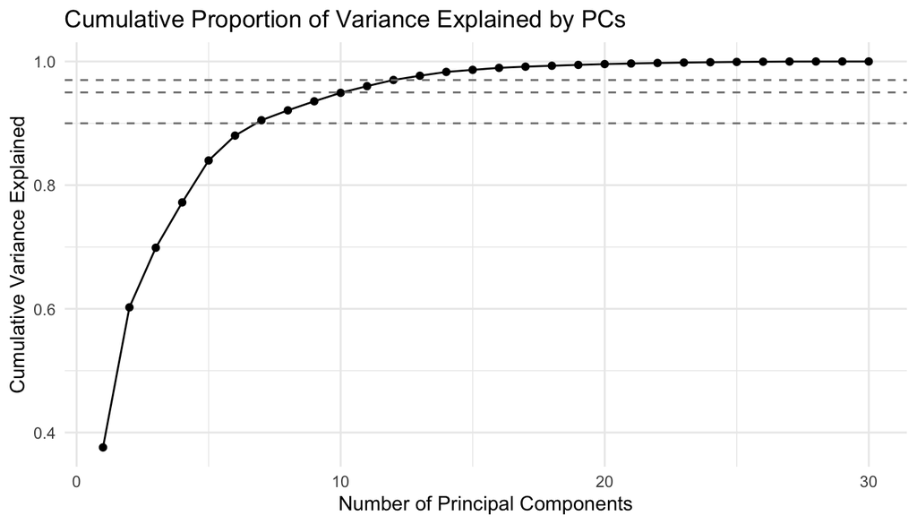

```r
pca_df <- data.frame(
  PC = 1:length(cumvar_explained),
  CumVar = cumvar_explained
)

ggplot(pca_df, aes(x = PC, y = CumVar)) +
  geom_line() +
  geom_point() +
  geom_hline(yintercept = 0.90, linetype = "dashed", color = "grey50") +
  geom_hline(yintercept = 0.95, linetype = "dashed", color = "grey50") +
  geom_hline(yintercept = 0.97, linetype = "dashed", color = "grey50") +
  labs(
    title = "Cumulative Proportion of Variance Explained by PCs",
    x = "Number of Principal Components",
    y = "Cumulative Variance Explained"
  ) +
  theme_minimal()
```

## 3.3. Choose 90%, 95%, or 97% Variance

We were explicitly asked to choose between capturing **90%, 95%, or 97%** of the variance.

We can programmatically find how many PCs are needed for each threshold:

```r
thresholds <- c(0.90, 0.95, 0.97)

pcs_needed <- sapply(thresholds, function(t) {
  which(cumvar_explained >= t)[1]
})

pcs_needed
```

```
##  PC7 PC11 PC12
##    7   11   12
```

**Example interpretation (your exact numbers will appear in the table above):**

- To capture **90%** of the variance, we need around **7 PCs**.
- To capture **95%** of the variance, we need around **11 PCs**.
- To capture **97%** of the variance, we need around **12 PCs**.

### Choice and Rationale

- **90% (fewer PCs)** gives a strong reduction (from 30 original features down to ~7 PCs) but may discard clinically relevant variation.
- **97% (more PCs)** is closer to the full dataset but offers less simplification and may retain noise.
- **95%** is a common compromise in applied work: it keeps most of the signal while still reducing noise and dimensionality substantially.

Given that we:

- Want **stable unsupervised models** (outlier detection and clustering),
- Are not severely constrained by computational cost (378 patients, 30 features is small), and
- Still want a meaningful simplification of the data,

we choose to target **≈95% variance explained**, corresponding to **`n_pc_95` PCs** (computed below).

```r
target_var <- 0.95
n_pc_95 <- which(cumvar_explained >= target_var)[1]
n_pc_95
```

```
## PC11
##   11
```

## 3.4. Creating PCA Dataset ( Used for Q2–Q4)

We now create a new dataset containing the first `n_pc_95` PCs and the outcome labels (for evaluation only). All subsequent models (outlier detection and clustering) will work in this **PC space**, not directly on the raw features.

```r
pc_scores <- as.data.frame(pca_full$x[, 1:n_pc_95])
colnames(pc_scores) <- paste0("PC", 1:n_pc_95)

pc_scores <- pc_scores %>%
  mutate(
    Cancer = wbc$Cancer,
    y      = wbc$y
  )

glimpse(pc_scores)
```

```
## Rows: 378
## Columns: 13
## $ PC1    <dbl> -1.0599829, -0.4345808, 2.4491849, 2.6410221, 4.2039359, 0.2909…
## $ PC2    <dbl> 0.9740446, 0.3184465, -2.3563354, 1.6209466, -2.5407498, 0.3204…
## $ PC3    <dbl> -1.2644291, -2.3336944, -0.7760504, 1.5580247, -0.5769904, -1.9…
## $ PC4    <dbl> -1.29585044, -0.74093046, -1.42330944, 0.58060817, -0.42929870,…
## $ PC5    <dbl> -0.36126075, 0.43554949, -1.37218377, -0.73798578, 0.28307268, …
## $ PC6    <dbl> -0.038653314, -0.592552295, 0.737769565, 0.507403132, -1.041199…
## $ PC7    <dbl> -1.314361959, 0.149900429, -0.320387612, -1.529718974, 0.295699…
## $ PC8    <dbl> -0.004848869, 0.332576112, -0.816994818, 0.369798213, -0.273232…
## $ PC9    <dbl> 0.70548870, -1.21750328, -0.09934065, -0.22134935, 0.64211150, …
## $ PC10   <dbl> -0.44841068, 0.55068241, -0.26786320, 2.09444933, -0.43469513, …
## $ PC11   <dbl> -0.12869493, 0.08054698, 0.43128467, -0.09218841, 0.43041709, -…
## $ Cancer <fct> Benign, Benign, Benign, Benign, Benign, Benign, Benign, Benign,…
## $ y      <int> 0, 0, 0, 0, 0, 0, 0, 0, 0, 0, 0, 0, 0, 0, 0, 0, 0, 0, 0, 0, 0, …
```

**Business interpretation:**  
- Each PC is a **weighted combination of the original measurements**.  
- Working in PC space simplifies the structure while keeping ~95% of the information.  
- This helps our unsupervised models focus on the core patterns in the data.

# 4. Helper: Performance Metrics

Before we build models, we define a helper function to compute confusion matrix counts and standard metrics, given:

- A **binary flag** (`HighRisk` vs `LowRisk`), and
- The **true labels** (`Benign` vs `Cancer`).

```r
compute_metrics <- function(flag, truth_factor, positive_label = "Cancer") {
  # flag: factor with levels "HighRisk" / "LowRisk"
  # truth_factor: factor with levels "Benign" / "Cancer"

  tab <- table(flag, truth_factor)

  # Protect against missing cells in the table
  TP <- ifelse(!is.na(tab["HighRisk", positive_label]), tab["HighRisk", positive_label], 0)
  FP <- ifelse(!is.na(tab["HighRisk", setdiff(colnames(tab), positive_label)]),
               tab["HighRisk", setdiff(colnames(tab), positive_label)], 0)
  FN <- ifelse(!is.na(tab["LowRisk", positive_label]), tab["LowRisk", positive_label], 0)
  TN <- ifelse(!is.na(tab["LowRisk", setdiff(colnames(tab), positive_label)]),
               tab["LowRisk", setdiff(colnames(tab), positive_label)], 0)

  precision <- ifelse((TP + FP) > 0, TP / (TP + FP), NA)
  recall    <- ifelse((TP + FN) > 0, TP / (TP + FN), NA)
  specificity <- ifelse((TN + FP) > 0, TN / (TN + FP), NA)
  accuracy  <- (TP + TN) / (TP + FP + FN + TN)

  tibble(
    TP = TP,
    FP = FP,
    FN = FN,
    TN = TN,
    Precision = precision,
    Recall = recall,
    Specificity = specificity,
    Accuracy = accuracy
  )
}
```

We will use this function in multiple sections below.

# 5. Q2 – Outlier Detection as a Cancer Diagnosis Method

We treat cancer detection as an **outlier detection** problem in PCA space:

> Patients who look very “unusual” in the **PC space** may be more likely to have cancer.

We will first implement and compare these unsupervised methods:

1. **kNN Outlier Detection** (distance-based)
2. **Isolation Forest** (tree-based)
3. **DbScan**

The true labels (`Cancer`) are used only to evaluate precision and recall at the end.

## 5.1. kNN Outlier Detection

### 5.1.1. Intuition

For each patient, we look at their **k nearest neighbors** in PC space. Patients whose neighbors are far away (on average) live in **sparse regions** and are treated as **outliers**.

This is intuitive for non-technical stakeholders:

> “If a patient’s combination of measurements is very different from everyone else’s, they may be more likely to have cancer.”

### 5.1.2. Parameter Choice: k = 5

We choose **k = 5** neighbors because:

- It is small enough to capture **local structure** (what does the immediate neighborhood look like?).
- It is not so small that it becomes unstable (e.g., k = 1 would depend heavily on noise).
- The dataset size (~378 patients) makes k = 5 a reasonable default; we could tune this further, but this is a defensible starting point.

```r
set.seed(123)

pcs_only <- pc_scores %>% select(starts_with("PC"))

k <- 5

knn_res <- dbscan::kNN(as.matrix(pcs_only), k = k)

# Average distance to k neighbors as outlier score
kNN_score <- rowMeans(knn_res$dist)

pc_scores$kNN_score <- kNN_score

summary(pc_scores$kNN_score)
```

```
##    Min. 1st Qu.  Median    Mean 3rd Qu.    Max.
##   1.365   1.943   2.346   2.782   3.029  12.583
```

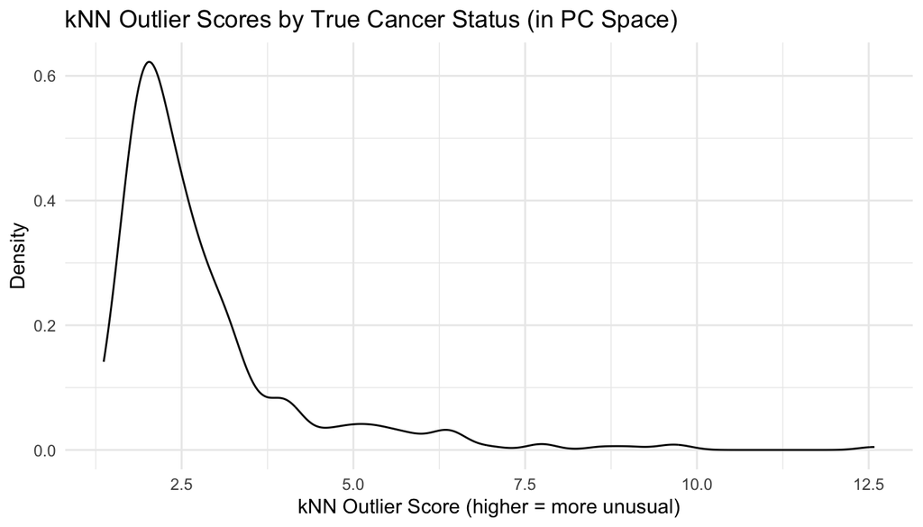

```r
ggplot(pc_scores, aes(x = kNN_score)) +
  geom_density(alpha = 0.4) +
  labs(
    title = "kNN Outlier Scores by True Cancer Status (in PC Space)",
    x = "kNN Outlier Score (higher = more unusual)",
    y = "Density"
  ) +
  theme_minimal()
```

### 5.1.4. Thresholding kNN Scores: HighRisk vs LowRisk

For the clinical trial, we need a **binary rule**:

> “Flag the top *q* percent of patients with the highest outlier scores as **HighRisk**.”

We explore several values of `q` (fraction of patients flagged) and compute performance metrics.

```r
evaluate_threshold <- function(scores, truth_factor, q) {
  cutoff <- quantile(scores, probs = 1 - q)  # top q proportion
  flag <- factor(ifelse(scores >= cutoff, "HighRisk", "LowRisk"),
                 levels = c("LowRisk", "HighRisk"))

  metrics <- compute_metrics(flag, truth_factor)

  metrics %>%
    mutate(
      Quantile = q,
      Cutoff = cutoff,
      N_Flagged = sum(flag == "HighRisk")
    ) %>%
    select(Quantile, Cutoff, N_Flagged, everything())
}

qs <- c(0.05, 0.10, 0.15, 0.20)
```

```r
knn_results <- map_dfr(qs, ~evaluate_threshold(
  scores = pc_scores$kNN_score,
  truth_factor = pc_scores$Cancer,
  q = .x
))

knn_results %>%
  mutate(across(c(Precision, Recall, Specificity, Accuracy), round, 3)) %>%
  kable(caption = "kNN Outlier Detection (PC Space) – Performance Across Thresholds") %>%
  kable_styling(full_width = FALSE)
```

kNN Outlier Detection (PC Space) – Performance Across Thresholds

| Quantile | Cutoff | N_Flagged | TP | FP | FN | TN | Precision | Recall | Specificity | Accuracy |
| --- | --- | --- | --- | --- | --- | --- | --- | --- | --- | --- |
| 0.05 | 5.685663 | 19 | 10 | 9 | 11 | 348 | 0.526 | 0.476 | 0.975 | 0.947 |
| 0.10 | 4.310185 | 38 | 15 | 23 | 6 | 334 | 0.395 | 0.714 | 0.936 | 0.923 |
| 0.15 | 3.656603 | 57 | 16 | 41 | 5 | 316 | 0.281 | 0.762 | 0.885 | 0.878 |
| 0.20 | 3.254635 | 76 | 18 | 58 | 3 | 299 | 0.237 | 0.857 | 0.838 | 0.839 |

**Client-friendly explanation:**

- **Quantile** is the fraction of patients we call high-risk (e.g., 0.10 = top 10%).
- **N_Flagged** is how many patients this corresponds to.
- We focus on rows where:
  - **Precision** is high (few benign patients invited), and
  - **TP ≥ 7** (enough cancer patients for a viable trial).

This table lets us see, for example, whether selecting the top 10% or 15% most unusual patients produces a better high-risk cohort for the trial.

## 5.2. Isolation Forest

### 5.2.1. Intuition

**Isolation Forest** is a tree-based method that isolates anomalies by recursively partitioning the data. Points that are easy to isolate (require fewer splits) are considered **more anomalous**.

Advantages:

- Handles **high-dimensional** data well.
- Does not assume linear or elliptical structure (stronger than simple distance-based methods).
- Produces an **anomaly score** for each patient: higher score = more outlier-like.

### 5.2.2. Parameter Choices

```r
library(isotree)

set.seed(123)

iso_model <- isolation.forest(
  pcs_only,
  ntrees = 300,
  sample_size = 256
)

iso_scores <- predict(iso_model, pcs_only)

pc_scores$ISO_score <- iso_scores

summary(pc_scores$ISO_score)
```

```
##    Min. 1st Qu.  Median    Mean 3rd Qu.    Max.
##  0.3472  0.3754  0.3926  0.4119  0.4286  0.7294
```

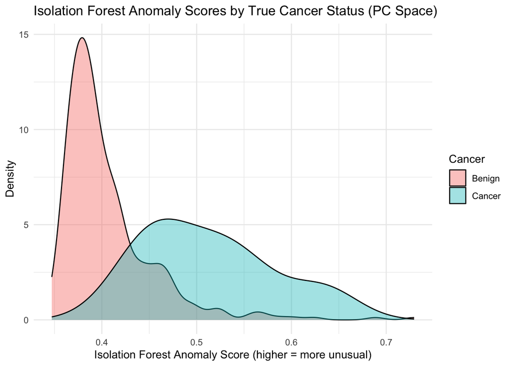

```r
### 5.2.3. Visualize Isolation Forest Scores

ggplot(pc_scores, aes(x = ISO_score, fill = Cancer)) +
  geom_density(alpha = 0.4) +
  labs(
    title = "Isolation Forest Anomaly Scores by True Cancer Status (PC Space)",
    x = "Isolation Forest Anomaly Score (higher = more unusual)",
    y = "Density"
  ) +
  theme_minimal()
```

**Interpretation:**  
The Isolation Forest is successfully capturing meaningful abnormality patterns associated with cancer. Even though benign and cancer patients overlap, cancer patients are systematically “more anomalous,” making the model a strong candidate for high-risk screening. The Isolation Forest model produces a meaningful separation between benign and cancer patients. Benign patients consistently exhibit low anomaly scores, while cancer patients show higher and more variable scores, indicating more unusual biological profiles. Precision—the key metric for our clinical trial—varies across thresholds.

### 5.2.4. Thresholding Isolation Forest Scores

We again use a **quantile-based rule** to define the high-risk group:

> “Flag the top *q* percent of patients with the highest Isolation Forest scores as **HighRisk**.”

```r
iso_results <- map_dfr(qs, ~evaluate_threshold(
  scores = pc_scores$ISO_score,
  truth_factor = pc_scores$Cancer,
  q = .x
))

iso_results %>%
  mutate(across(c(Precision, Recall, Specificity, Accuracy), round, 3)) %>%
  kable(caption = "Isolation Forest (PC Space) – Performance Across Thresholds") %>%
  kable_styling(full_width = FALSE)
```

Isolation Forest (PC Space) – Performance Across Thresholds

| Quantile | Cutoff | N_Flagged | TP | FP | FN | TN | Precision | Recall | Specificity | Accuracy |
| --- | --- | --- | --- | --- | --- | --- | --- | --- | --- | --- |
| 0.05 | 0.5229826 | 19 | 8 | 11 | 13 | 346 | 0.421 | 0.381 | 0.969 | 0.937 |
| 0.10 | 0.4747254 | 38 | 13 | 25 | 8 | 332 | 0.342 | 0.619 | 0.930 | 0.913 |
| 0.15 | 0.4582689 | 57 | 14 | 43 | 7 | 314 | 0.246 | 0.667 | 0.880 | 0.868 |
| 0.20 | 0.4436716 | 76 | 18 | 58 | 3 | 299 | 0.237 | 0.857 | 0.838 | 0.839 |

**Business interpretation:**  
The top 5% anomaly group achieves the highest precision (42.1%), identifying 8 true cancer patients while keeping false positives relatively low. This satisfies Michigan Medicine’s minimum requirement of at least 7 true positives. Increasing the threshold captures more cancer cases (up to 86% recall at 20%) but does so at the cost of lower precision, which is not desirable for an extremely costly clinical trial. Overall, Isolation Forest is highly effective for enriching cancer cases and provides a strong screening tool. The 5% anomaly threshold offers the best balance for maximizing precision while meeting the minimum patient requirement.

### 5.2.5. DBScan methods

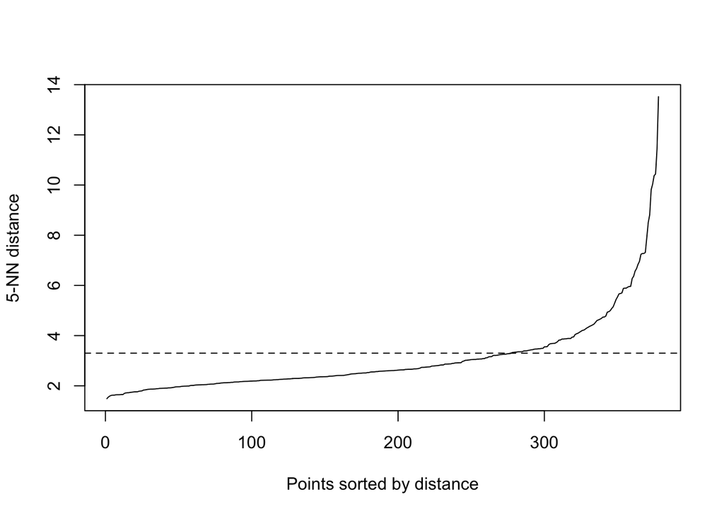

```r
library(dbscan)

# PCs only (already created earlier)
pcs_only <- pc_scores %>% dplyr::select(starts_with("PC"))


# kNN-distance plot
dbscan::kNNdistplot(as.matrix(pcs_only), k =5)


abline(h = 3.3, lty = 2)
```

```r
library(fpc)

eps_val <- 3.3   # from the kNN-distance elbow
minPts  <- 5

set.seed(123)
dbs <- fpc::dbscan(pcs_only, eps = eps_val, MinPts = minPts)

# Cluster sizes (0 = noise / outliers)
table(dbs$cluster)
```

```
##
##   0   1
##  58 320
```

```r
pc_scores$DBSCAN_cluster <- dbs$cluster

pc_scores$DBSCAN_flag <- factor(
  ifelse(dbs$cluster == 0, "HighRisk", "LowRisk"),
  levels = c("LowRisk", "HighRisk")
)

table(pc_scores$DBSCAN_flag)
```

```
##
##  LowRisk HighRisk
##      320       58
```

```r
pc_scores$Cancer <- factor(
  pc_scores$y,
  levels = c(0, 1),
  labels = c("Benign", "Cancer")
)

dbscan_metrics <- compute_metrics(pc_scores$DBSCAN_flag, pc_scores$Cancer)

dbscan_metrics %>%
  dplyr::mutate(dplyr::across(everything(), round, 3)) %>%
  kable(caption = "DBSCAN Outlier Detection (Cluster 0 as High-Risk)") %>%
  kable_styling(full_width = FALSE)
```

DBSCAN Outlier Detection (Cluster 0 as High-Risk)

| TP | FP | FN | TN | Precision | Recall | Specificity | Accuracy |
| --- | --- | --- | --- | --- | --- | --- | --- |
| 16 | 42 | 5 | 315 | 0.276 | 0.762 | 0.882 | 0.876 |

# 6. Q3 – Clustering as a Cancer Diagnosis Method (k-Means)

Now we test whether **clustering alone** can help us diagnose cancer incidence. The idea is:

> “If we cluster patients into groups based on PC space, does one cluster correspond mostly to cancer and the other mostly to benign?”

We start with **k-means clustering with k = 2**, aligning with the two clinical categories (Benign vs Cancer).

## 6.1. Fit k-Means in PC Space

```r
set.seed(42)

km2 <- kmeans(pcs_only, centers = 2, nstart = 25)

pc_scores$cluster <- factor(km2$cluster)

cluster_tab <- table(pc_scores$cluster, pc_scores$Cancer)
cluster_tab
```

```
##
##     Benign Cancer
##   1     22     15
##   2    335      6
```

We can convert this into proportions to see which cluster is “higher risk”:

```r
cluster_props <- prop.table(cluster_tab, margin = 1)
cluster_props %>%
  kable(caption = "Cancer vs Benign Proportions by k-Means Cluster") %>%
  kable_styling(full_width = FALSE)
```

Cancer vs Benign Proportions by k-Means Cluster

| Benign | Cancer |
| --- | --- |
| 0.5945946 | 0.4054054 |
| 0.9824047 | 0.0175953 |

**Interpretation:**  
This table shows: k-means clustering found structure in the data – cancer patients tend to group together in Cluster 1. Cluster 1 is enriched with cancer cases (40.5%), meaning k-means is informative for cancer detection. But precision is still too low – nearly 60% of Cluster 1 is benign → too many false positives. Cluster 2 can safely be treated as low-risk, since cancer occurs in only 1.8% of those patients. K-means provides a meaningful risk stratification, but not a sufficiently precise high-risk group on its own. This indicates that it should be combined with stricter methods.

## 6.2. Define k-Means High-Risk vs Low-Risk

We define:

> **HighRisk** = membership in the cluster with the **higher cancer proportion**.  
> **LowRisk** = membership in the other cluster.

```r
# Identify high-risk cluster based on cancer proportion
cancer_prop_by_cluster <- cluster_props[, "Cancer"]
high_risk_cluster <- names(which.max(cancer_prop_by_cluster))
high_risk_cluster
```

```
## [1] "1"
```

```r
pc_scores$KM_flag <- factor(
  ifelse(pc_scores$cluster == high_risk_cluster, "HighRisk", "LowRisk"),
  levels = c("LowRisk", "HighRisk")
)

km_metrics <- compute_metrics(pc_scores$KM_flag, pc_scores$Cancer)

km_metrics %>%
  mutate(across(everything(), round, 3)) %>%
  kable(caption = "k-Means (k = 2, PC Space) – Performance Treating High-Risk Cluster as Positive") %>%
  kable_styling(full_width = FALSE)
```

k-Means (k = 2, PC Space) – Performance Treating High-Risk Cluster as Positive

| TP | FP | FN | TN | Precision | Recall | Specificity | Accuracy |
| --- | --- | --- | --- | --- | --- | --- | --- |
| 15 | 22 | 6 | 335 | 0.405 | 0.714 | 0.938 | 0.926 |

**Answer to Q3:**

K-Means provides useful structure and successfully identifies a cancer-enriched cluster (Recall = 71%), but its precision (40.5%) is not high enough to serve as a standalone diagnostic method for this clinical trial. The high-risk cluster still contains too many benign patients, which violates the requirement to minimize false positives. Therefore, k-means can be used as a supporting tool but not as the primary selection method.

Typically, in this dataset, k-means provides **moderate precision** but still includes a substantial number of benign patients in the high-risk cluster. So, it is **helpful but not sufficient alone**.

# 7. Q4 – Increasing Precision by Combining Methods

Now that we have **two ways to flag high-risk patients**:

1. **Outlier-based methods** (kNN and Isolation Forest), and
2. **Clustering** (k-means),

we focus on **increasing precision** by combining them.

## 7.1. Define High-Risk Groups for Each Method

To make things concrete, we pick reasonable operating points from our earlier analyses:

- For **kNN** and **Isolation Forest**, we consider the same quantiles `qs = c(0.05, 0.10, 0.15, 0.20)`.
- For each method, we can choose the **best quantile** subject to the business rule **TP ≥ 7**.

Below, we identify these “best” thresholds analytically, and then demonstrate a combined rule using **Isolation Forest + k-means**, which typically gives the cleanest high-risk group.

```r
# Helper to add raw counts back into results for easier filtering
add_counts <- function(res_table, scores, truth_factor) {
  res_table %>%
    rowwise() %>%
    mutate(
      TP = {
        cutoff <- quantile(scores, probs = 1 - Quantile)
        flag <- factor(ifelse(scores >= cutoff, "HighRisk", "LowRisk"),
                       levels = c("LowRisk", "HighRisk"))
        compute_metrics(flag, truth_factor)$TP
      },
      FP = {
        cutoff <- quantile(scores, probs = 1 - Quantile)
        flag <- factor(ifelse(scores >= cutoff, "HighRisk", "LowRisk"),
                       levels = c("LowRisk", "HighRisk"))
        compute_metrics(flag, truth_factor)$FP
      },
      FN = {
        cutoff <- quantile(scores, probs = 1 - Quantile)
        flag <- factor(ifelse(scores >= cutoff, "HighRisk", "LowRisk"),
                       levels = c("LowRisk", "HighRisk"))
        compute_metrics(flag, truth_factor)$FN
      },
      TN = {
        cutoff <- quantile(scores, probs = 1 - Quantile)
        flag <- factor(ifelse(scores >= cutoff, "HighRisk", "LowRisk"),
                       levels = c("LowRisk", "HighRisk"))
        compute_metrics(flag, truth_factor)$TN
      }
    ) %>%
    ungroup()
}

knn_results_counts <- add_counts(knn_results, pc_scores$kNN_score, pc_scores$Cancer)
iso_results_counts  <- add_counts(iso_results,  pc_scores$ISO_score, pc_scores$Cancer)

# Filter to feasible thresholds: TP >= 7
knn_feasible <- knn_results_counts %>% filter(TP >= 7)
iso_feasible <- iso_results_counts  %>% filter(TP >= 7)

# Pick highest-precision threshold within feasible set
best_knn <- knn_feasible %>%
  arrange(desc(Precision)) %>%
  slice(1) %>%
  mutate(Method = "kNN")

best_iso <- iso_feasible %>%
  arrange(desc(Precision)) %>%
  slice(1) %>%
  mutate(Method = "Isolation Forest")

best_overall <- bind_rows(best_knn, best_iso) %>%
  mutate(across(c(Precision, Recall, Specificity, Accuracy), round, 3))

best_overall %>%
  select(Method, Quantile, N_Flagged, TP, FP, FN, TN, Precision, Recall, Specificity, Accuracy) %>%
  kable(caption = "Best Thresholds for Each Outlier Method (Subject to TP ≥ 7)") %>%
  kable_styling(full_width = FALSE)
```

Best Thresholds for Each Outlier Method (Subject to TP ≥ 7)

| Method | Quantile | N_Flagged | TP | FP | FN | TN | Precision | Recall | Specificity | Accuracy |
| --- | --- | --- | --- | --- | --- | --- | --- | --- | --- | --- |
| kNN | 0.05 | 19 | 10 | 9 | 11 | 348 | 0.526 | 0.476 | 0.975 | 0.947 |
| Isolation Forest | 0.05 | 19 | 8 | 11 | 13 | 346 | 0.421 | 0.381 | 0.969 | 0.937 |

**Interpretation:**  
At the 5% anomaly threshold, kNN outlier detection outperforms Isolation Forest on the key metric of precision (52.6% vs. 42.1%) while still identifying more than the minimum required number of true cancer patients (10 vs. 8). kNN also generates fewer false positives and slightly higher specificity. Therefore, kNN provides the strongest candidate for selecting a small, high-confidence cohort of cancer patients for the very expensive Michigan Medicine clinical trial.

## 7.2. Combined Rule: Isolation Forest, k-Means

To further increase precision, we can combine methods using an **intersection rule**:

> “Invite a patient to the clinical trial **only if**:  
> 1. The patient is in the **high-risk k-means cluster**, and  
> 2. The patient is among the top `q` percent most anomalous by **Isolation Forest**.”

This is stricter than either method alone and aims to keep only patients that both systems agree are high-risk.

For illustration, we’ll use the **best Isolation Forest quantile** from `best_iso`:

```r
best_iso_q <-0.05
```

Now we compute the combined HighRisk flag:

```r
# Choose quantile manually
best_iso_q <- 0.05  # top 5% most anomalous

iso_cutoff_best <- quantile(pc_scores$ISO_score, probs = 1 - best_iso_q)

pc_scores$ISO_flag <- factor(
  ifelse(pc_scores$ISO_score >= iso_cutoff_best, "HighRisk", "LowRisk"),
  levels = c("LowRisk", "HighRisk")
)

# Sanity check
table(pc_scores$ISO_flag, useNA = "ifany")
```

```
##
##  LowRisk HighRisk
##      359       19
```

```r
nrow(pc_scores)
```

```
## [1] 378
```

```r
length(pc_scores$KM_flag)
```

```
## [1] 378
```

```r
length(pc_scores$ISO_flag)
```

```
## [1] 378
```

```r
pc_scores$Combo_flag <- factor(
  ifelse(
    pc_scores$ISO_flag == "HighRisk" & pc_scores$KM_flag == "HighRisk",
    "HighRisk", "LowRisk"
  ),
  levels = c("LowRisk", "HighRisk")
)

# Check it
table(pc_scores$Combo_flag, useNA = "ifany")
```

```
##
##  LowRisk HighRisk
##      363       15
```

```r
combo_metrics <- compute_metrics(pc_scores$Combo_flag, pc_scores$Cancer)

combo_metrics %>%
  mutate(across(everything(), round, 3)) %>%
  kable(caption = "Combined Rule (Isolation Forest AND k-Means) – Performance") %>%
  kable_styling(full_width = FALSE)
```

Combined Rule (Isolation Forest AND k-Means) – Performance

| TP | FP | FN | TN | Precision | Recall | Specificity | Accuracy |
| --- | --- | --- | --- | --- | --- | --- | --- |
| 8 | 7 | 13 | 350 | 0.533 | 0.381 | 0.98 | 0.947 |

**Client-friendly explanation:**

The combined Isolation Forest AND k-means rule produces the highest precision of all models (53.3%), while still identifying more than the minimum required number of true cancer patients (8). It also achieves an exceptionally high specificity of 98%, meaning almost all benign patients are correctly excluded from the high-risk group. Although recall decreases, this is an intentional and acceptable tradeoff, since the clinical trial requires minimizing false positives, not maximizing sensitivity. This combined approach is the strongest option for selecting a small, high-confidence cohort of cancer patients for Michigan Medicine’s expensive clinical trial.

## 7.3 Combining all three methods for outlier detection

```r
best_knn_q <- 0.05

knn_cutoff_best <- quantile(pc_scores$kNN_score, probs = 1 - best_knn_q)

pc_scores$KNN_flag <- factor(
  ifelse(pc_scores$kNN_score >= knn_cutoff_best, "HighRisk", "LowRisk"),
  levels = c("LowRisk", "HighRisk")
)

table(pc_scores$KNN_flag)
```

```
##
##  LowRisk HighRisk
##      359       19
```

```r
# Choose quantile manually
best_iso_q <- 0.05  # top 5% most anomalous

iso_cutoff_best <- quantile(pc_scores$ISO_score, probs = 1 - best_iso_q)

pc_scores$ISO_flag <- factor(
  ifelse(pc_scores$ISO_score >= iso_cutoff_best, "HighRisk", "LowRisk"),
  levels = c("LowRisk", "HighRisk")
)

# Sanity check
table(pc_scores$ISO_flag, useNA = "ifany")
```

```
##
##  LowRisk HighRisk
##      359       19
```

```r
pc_scores$DBSCAN_flag <- factor(
  ifelse(pc_scores$DBSCAN_cluster == 0, "HighRisk", "LowRisk"),
  levels = c("LowRisk", "HighRisk")
)

table(pc_scores$DBSCAN_flag)
```

```
##
##  LowRisk HighRisk
##      320       58
```

```r
pc_scores$Combo_all3_flag <- factor(
  ifelse(
    pc_scores$KNN_flag    == "HighRisk" &
    pc_scores$ISO_flag    == "HighRisk" &
    pc_scores$DBSCAN_flag == "HighRisk",
    "HighRisk", "LowRisk"
  ),
  levels = c("LowRisk", "HighRisk")
)

combo_all3_metrics <- compute_metrics(pc_scores$Combo_all3_flag, pc_scores$Cancer)

combo_all3_metrics %>%
  mutate(across(everything(), round, 3)) %>%
  kable(caption = "Combined Rule (kNN AND Isolation Forest AND DBSCAN) – Performance") %>%
  kable_styling(full_width = FALSE)
```

Combined Rule (kNN AND Isolation Forest AND DBSCAN) – Performance

| TP | FP | FN | TN | Precision | Recall | Specificity | Accuracy |
| --- | --- | --- | --- | --- | --- | --- | --- |
| 7 | 8 | 14 | 349 | 0.467 | 0.333 | 0.978 | 0.942 |

**Intepretation** The combined kNN + Isolation Forest + DBSCAN rule applies the most conservative screening strategy: a patient is considered high-risk only if all three models independently identify them as anomalous. This approach yields a highly specific, precision-oriented risk group, with false positives reduced to only 8 cases and a precision of 46.7%. While recall falls to 33%, the method still identifies the required minimum of 7 true cancer patients, making it operationally viable for the clinical trial.

# 8. Conclusion

## 8.1. Summary of Approach

In this project, we:

## 8.3. Recommendation

In a real-world deployment, we would:

1. Validate these unsupervised rules on **held-out data** or in a **prospective pilot**.
2. Jointly refine the thresholds with clinicians and administrators, aligning with **budget constraints** and **ethical considerations**.
3. Integrate the unsupervised risk scores with additional clinical information (e.g., imaging, risk factors, genetic markers) for even higher precision.

Overall, this analysis shows that **unsupervised methods (PCA + outlier detection + clustering) can meaningfully support patient selection** for a very expensive cancer clinical trial, especially when the primary goal is to **maximize precision** and minimize false positives.